# Project1

Kevin Francis

2/21/2021

# Data Description

The data I choose is made up by life expectancy and alcohol consumption. The life expectancy is the average for a country, and the alcohol is liters per person. I am interested in seeing if there is a relationship between how much the average person drinks and their life expectancy.

```r
#Reading in the data
data <- read.csv("LifeExpectancyData.csv") %>%
  dplyr::select(LifeExpectancy, Alcohol)

#Reducing the size of the data
data <- data %>%
  slice(-seq(0.25 * n()))

#Removing incomplete pairs of data
data <- na.omit(data)

#Displaying the data
datatable(data, class = 'display')
```

|  | LifeExpectancy | Alcohol |
| --- | --- | --- |
| 1 | 52.1 | 1.85 |
| 2 | 51.8 | 1.9 |
| 3 | 51.3 | 1.98 |
| 5 | 84 | 9.64 |
| 6 | 81 | 9.5 |
| 7 | 80 | 9.26 |
| 8 | 79.7 | 10.47 |
| 9 | 79.2 | 10.28 |
| 10 | 78.9 | 10.08 |
| 11 | 78.8 | 10.7 |

[output cut: 2036 more lines]

```r
#Generating summary statistics for the data
lifeEx_summ <- data %>%
  summarise(mean = mean(LifeExpectancy), sd = sd(LifeExpectancy), median = median(LifeExpectancy), IQR = IQR(LifeExpectancy), mode = getmode(LifeExpectancy), sampeSize = length(LifeExpectancy))
alc_summ <- data %>%
  summarise(mean = mean(Alcohol), sd = sd(Alcohol), median = median(Alcohol),   IQR = IQR(Alcohol), mode = getmode(Alcohol), sampeSize = length(Alcohol))

#Neatly displaying the summary statistics
cols <- c('Life Expectancy', 'Alcohol')
col.Variable <- data.frame(cols)
summ1 <- rbind(lifeEx_summ, alc_summ)
summ <- cbind2(col.Variable, summ1)
knitr::kable(summ, align='lccrr', caption = 'Mean, Standard Deviation, Median, and IQR of the data', col.names = c('Variable', 'Mean', 'Standard Deviation', 'Median', 'IQR', 'Mode', 'Sample Size'))
```

Mean, Standard Deviation, Median, and IQR of the data

| Variable | Mean | Standard Deviation | Median | IQR | Mode | Sample Size |
| --- | --- | --- | --- | --- | --- | --- |
| Life Expectancy | 69.30533 | 9.348368 | 71.90 | 11.9000 | 73.00 | 2046 |
| Alcohol | 4.45846 | 4.029834 | 3.28 | 6.8025 | 0.01 | 2046 |

## Distribution and Scatter Plots

Below are density plots for the predictor and the outcome. These can help give some insight into the range, mean, and possible outliers for each variable. If a variable has extreme outliers, it can give a starting point to finding anomalies or unexpected results. The scatter plot can help with an initial eye test. Does the plot tend upward, downward, or possibly even flat. Those are some of the things an initial scatter plot can help identify.

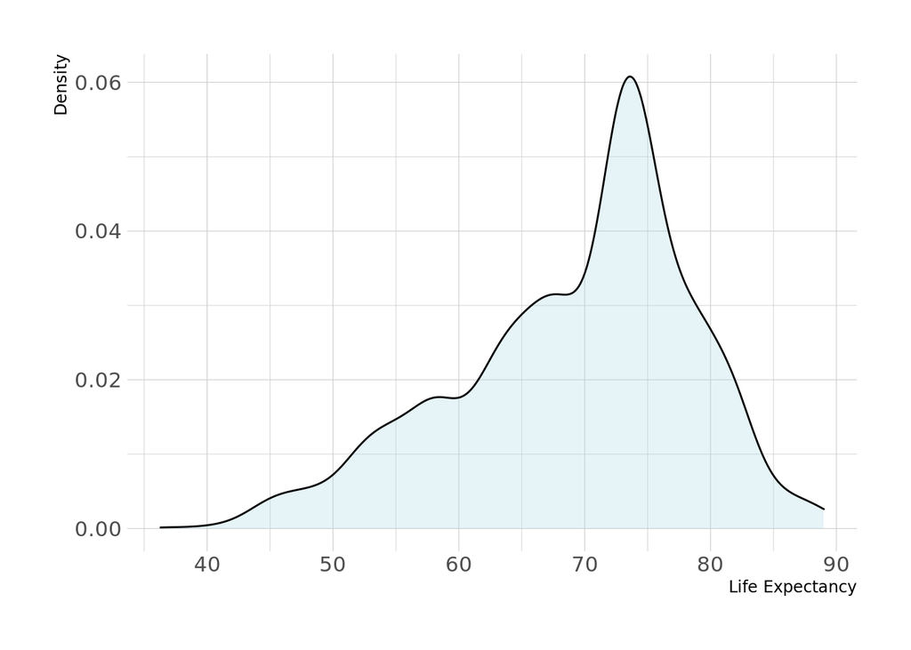

```r
ggplot(data=data, aes(x=data$LifeExpectancy)) +
    geom_density(alpha=.3, fill='lightblue') +
    theme_ipsum_es() +
    xlab('Life Expectancy') +
    ylab('Density')
```

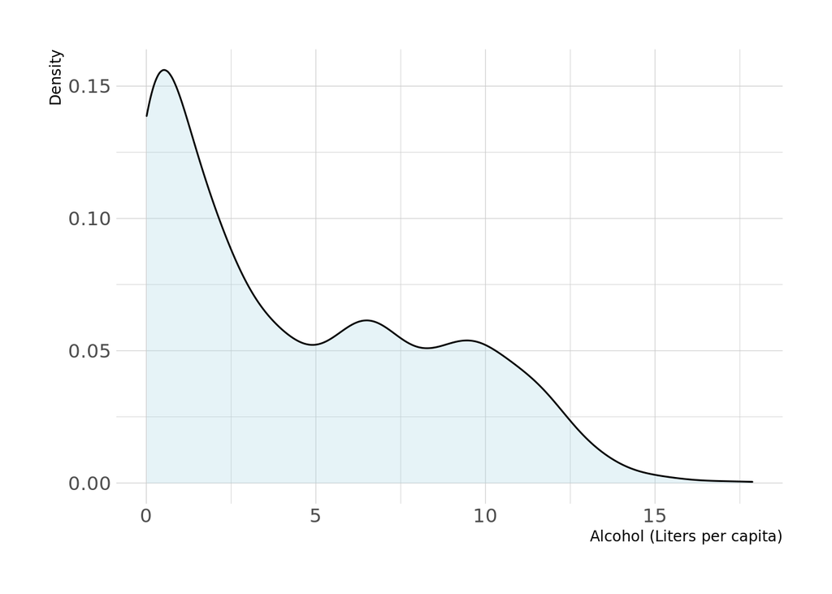

```r
ggplot(data=data, aes(x=data$Alcohol)) +
    geom_density(alpha=.3, fill='lightblue') +
    theme_ipsum_es() +
    xlab('Alcohol (Liters per capita)') +
    ylab('Density')
```

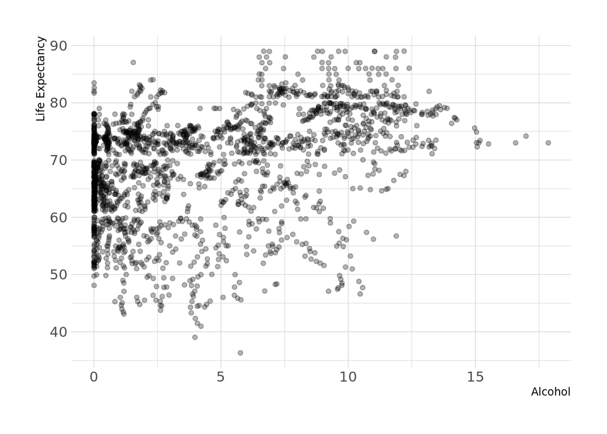

```r
ggplot(data=data, aes(x=data$Alcohol, y=data$LifeExpectancy)) +
    geom_jitter(alpha=.3) +
    theme_ipsum_es() +
    xlab('Alcohol') +
    ylab('Life Expectancy')
```

# Regression Model

```r
#Creating the linear model
model <- lm(LifeExpectancy ~ Alcohol, data=data)
#Getting the coefficients from the model
coef <- coefficients(model)
summary <- summary(model)
#Finding the confidence interval for each parameter
ci <- as_tibble(confint(model, level=0.95))
t <- as_tibble(summary[[4]])
```

```r
#Adding a variable column to table
Variable <- c('Intercept', 'Alcohol')
col.Variable2 <- data.frame(Variable)
summ3 <- cbind2(col.Variable2, t)
knitr::kable(summ3, align='lccrr')
```

| Variable | Estimate | Std. Error | t value | Pr(>\|t\|) |
| --- | --- | --- | --- | --- |
| Intercept | 65.3652760 | 0.2850826 | 229.2854 | 0 |
| Alcohol | 0.8837247 | 0.0474417 | 18.6276 | 0 |

The resulting regression model is:
$$\hat{Y} = 65.37 + 0.88X_{\mbox{Alcohol}}$$

For each increase in alcohol consumption, we expect life expectancy to increase by 0.88.

# Confidence Interval for $\beta_1$

The confidence interval for alcohol is (0.79, 0.98). This is the interval that contains the true value of $\beta_1$ for 95% of samples.

# Testing for Significance

**Hypotheses**

$H_0: \ \beta_1 = 0$  
$H_1: \ \beta_1 \ne 0$

**Test Statistic**

$t_0 = 18.63$.

*p*-value

$p < 0.0001$.

**Rejection Region**

Reject if $p < \alpha$, where $\alpha=0.05$.

**Conclusion and Interpretation**

Reject $H_0$. There is sufficient evidence to suggest that alcohol intake is a significant predictor of life expectancy.

# $R^2$

$R^2=0.15$; that is, approximately 15% of the variance in life expectancy is explained by the current model (Alcohol consumption in liters per person). This tells us that a good portion of the variation in the data is not covered by this model.

# Conclusion

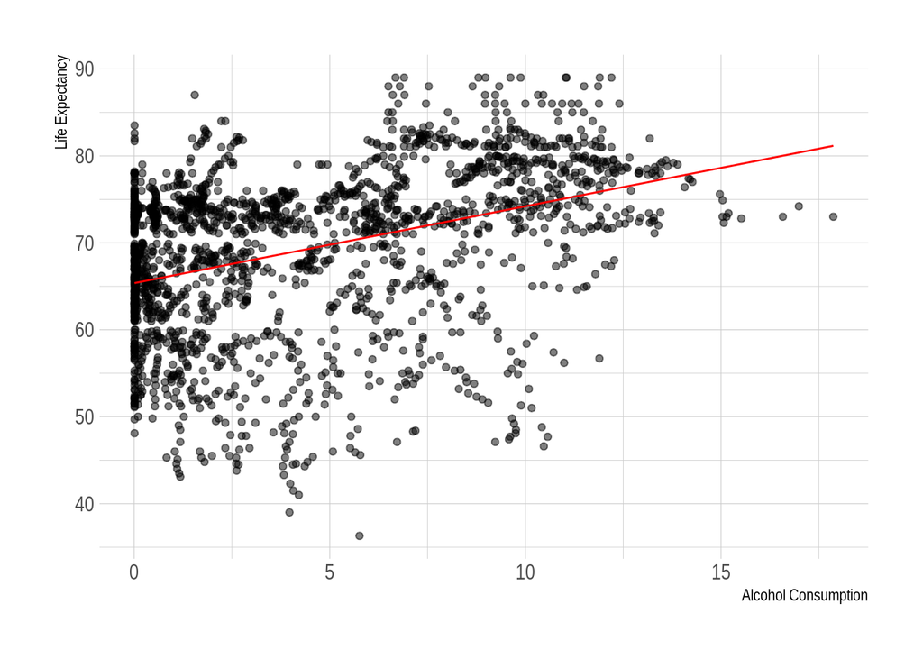

```r
data$pred <- coef[[1]] + coef[[2]]*data$Alcohol
ggplot(data=data, aes(x=data$Alcohol, y=data$LifeExpectancy)) +
    geom_point(alpha=.5) +
    theme_ipsum() +
    xlab('Alcohol Consumption') +
    ylab('Life Expectancy')+
    geom_line(aes(y = data$pred), color = "red", linetype = "solid")
```

Above is a plot shows the regression line over the data. The line does go through the data, but some spots you can see the error is fairly high. While the model “works”, I would like to see more of the variability covered.